# Assingment1_MS

2025-09-29

## Task 1: Literature

1.Read articles.

2.a Van Bruggen et al. explored early oligodendrogenesis in the human ventral brain (postconception weeks (PCW) 8-11 weeks) using single cell transcriptome, epigenomics, spatial in situ sequencing, and RNAscope. They found that as early as PCW8, radial glial cells start being specified in the ventral forebrain into the oligodendrocyte (OL) lineage. This data suggested the first wave of olivodendrogenesis indeed occurs early in the first trimester of human development.

2.b

single cell RNA seq

single cell ATAC seq

Hybridization-based in situ sequencing

RNAscope

3.a.

1. Elucidating human-specific mechanisms of oligodendrogenesis I am interested in clarifying how the early waves of oligodendrocyte precursor cell (OPC) differentiation observed in human forebrain differ from # other animal models. It would be great if we could identify human-specific developmental trajectries.
2. Integrative analysis of transcriptional and epigenetic regulatory network I am interested in other epigenetic information to explore regulatory network. If we could add 3 genome architecture, it would be helpful to understand the transcription factor networks and epigenetic programs driving OPC emergence.
3. Application to disease modeling  
   Leveraging the developmental reference map to compare with disease-drived iPSC or brain organoid models, we could understand the mechanisms of neurodevelopmental diseaese.

3.b.

1. Integrate cross-species single cell datasets with Harmony, align homologous populations using SAMap, and reconstruct trajectories via RNA velocity and quantify human-specific states using DAseq and ligand receptor network inference using Cellchat.
2. Integrate Hi-C/ABCmodels with pseudotime tradeSeq to identify dynamic regulatory swtich during early oligodendrogenesis.
3. Map disease iPSC/organoid data onto fetal reference via scArches, quantify trajectory deviations with velocity and optimal transport, integrate GWAS-eQTL colocalization, and assess altered cell composition and signaling networks.

## Task 2

Start a new project in a Gitlab, Github or Figshare repository.

https://github.com/msatoh07/RIKENcourse

## Task 3

```r
library(tidyverse)
```

## Task 4

```r
# 1
sqrt(10)
```

```
## [1] 3.162278
```

```r
# 2
log2(32)
```

```
## [1] 5
```

```r
# 3
sum(1:1000)
```

```
## [1] 500500
```

```r
# 4
sum(seq(2, 1000, by = 2))
```

```
## [1] 250500
```

```r
# 5
n <- 100
pairs <- choose(n, 2)
pairs
```

```
## [1] 4950
```

```r
# 6
choose(100,3)
```

```
## [1] 161700
```

## Task 5

```r
# 1
data (CO2)
head (CO2)
```

```
##   Plant   Type  Treatment conc uptake
## 1   Qn1 Quebec nonchilled   95   16.0
## 2   Qn1 Quebec nonchilled  175   30.4
## 3   Qn1 Quebec nonchilled  250   34.8
## 4   Qn1 Quebec nonchilled  350   37.2
## 5   Qn1 Quebec nonchilled  500   35.3
## 6   Qn1 Quebec nonchilled  675   39.2
```

```r
# 2
help(CO2)
```

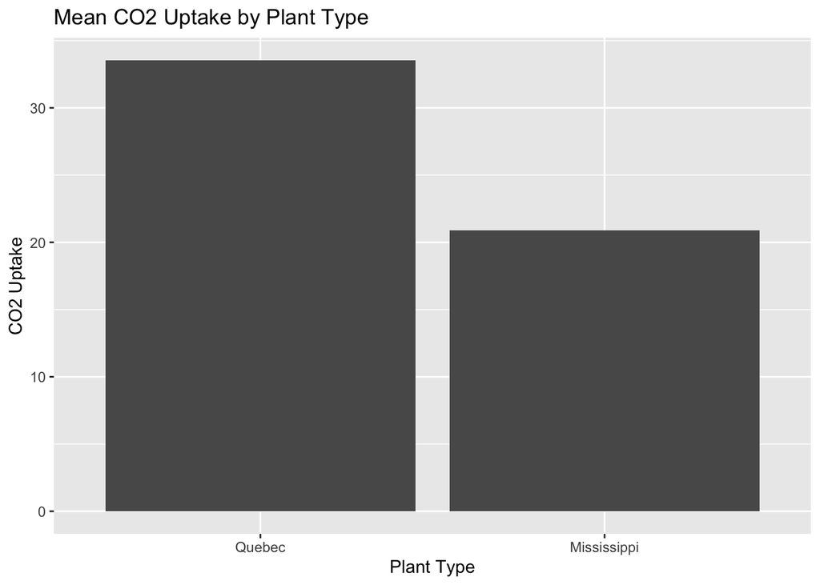

```r
# 3
library(dplyr)

summary_vals <- CO2 %>%
  group_by(Type) %>%
  summarise(
    mean_uptake = mean(uptake),
    median_uptake = median(uptake)
  )

# mean
ggplot(summary_vals, aes(x = Type, y = mean_uptake)) +
  geom_col(position = "dodge") +
  labs(title = "Mean CO2 Uptake by Plant Type",
       x = "Plant Type",
       y = "CO2 Uptake")
```

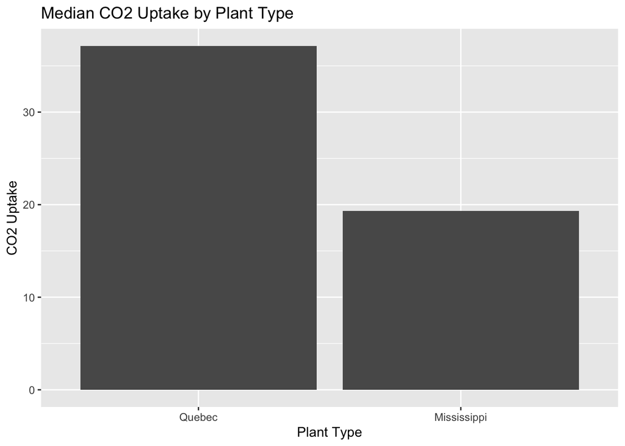

```r
#median
ggplot(summary_vals, aes(x = Type, y = median_uptake)) +
  geom_col(position = "dodge") +
  labs(title = "Median CO2 Uptake by Plant Type",
       x = "Plant Type",
       y = "CO2 Uptake")
```

```r
# 4
#if (!requireNamespace("airway", quietly = TRUE)) {
#  BiocManager::install("airway")
#}

library(airway)
library(SummarizedExperiment)

data("airway")
head(airway)
```

```
## class: RangedSummarizedExperiment
## dim: 6 8
## metadata(1): ''
## assays(1): counts
## rownames(6): ENSG00000000003 ENSG00000000005 ... ENSG00000000460
##   ENSG00000000938
## rowData names(10): gene_id gene_name ... seq_coord_system symbol
## colnames(8): SRR1039508 SRR1039509 ... SRR1039520 SRR1039521
## colData names(9): SampleName cell ... Sample BioSample
```

```r
counts <- assay(airway)   # matrix of counts
dim(counts)               # genes x samples
```

```
## [1] 63677     8
```

```r
# count expressed genes per sample
genes_expressed_per_sample <- colSums(counts > 0)
genes_expressed_per_sample
```

```
## SRR1039508 SRR1039509 SRR1039512 SRR1039513 SRR1039516 SRR1039517 SRR1039520
##      24633      24527      25699      23124      25508      25998      24662
## SRR1039521
##      23991
```

```r
# count non-expressed genes per sample
genes_not_expressed <- sum(rowSums(counts > 0) == 0)
genes_not_expressed
```

```
## [1] 30208
```

```r
summary(genes_expressed_per_sample)
```

```
##    Min. 1st Qu.  Median    Mean 3rd Qu.    Max.
##   23124   24393   24648   24768   25556   25998
```

## Task 6

```r
# 1
ratio_mean_median <- function(x) {
  mean(x, na.rm = TRUE) / median(x, na.rm = TRUE)
}

# Example
ratio_mean_median(c(1, 10, 100))
```

```
## [1] 3.7
```

```r
# 2
mean_trim_extremes <- function(x) {
  x_sorted <- sort(x, na.last = NA)
  if (length(x_sorted) <= 2) {
    return(NA)  # not enough values
  }
  mean(x_sorted[-c(1, length(x_sorted))], na.rm = TRUE)
}

# Example
mean_trim_extremes(c(1, 5, 6, 7, 10))
```

```
## [1] 6
```

```r
# 3
pipe_explanation <- "Weshouldavoidpipeswhenchainsexceedmorethan10stepswhencombiningmultipleinputs/output,orwhenmodelingcomplex"
```

```r
# 4
apply_explanation <- "Wecanreducetheneedforloopsbyapplyingafunctiontodataobjects"
```

## Task 7

```r
#install.packages("remotes")
library(remotes)
#install_url("http://emotion.utu.fi/wp-content/uploads/2019/11/nummenmaa_1.0.tar.gz",
#            dependencies = TRUE)
```

```r
# 1
library(tidyverse)
magic_guys <-read.csv("Data/magic_guys.csv")
head(magic_guys)
```

```
##   uniqId species length weight
## 1     p1    jedi  174.6   71.3
## 2     p2    jedi  252.2   70.8
## 3     p3    jedi  229.8   70.7
## 4     p4    jedi  176.2   80.4
## 5     p5    jedi  213.3   82.0
## 6     p6    jedi  112.5   64.2
```

```r
magic_guys$species
```

```
##   [1] "jedi" "jedi" "jedi" "jedi" "jedi" "jedi" "jedi" "jedi" "jedi" "jedi"
##  [11] "jedi" "jedi" "jedi" "jedi" "jedi" "jedi" "jedi" "jedi" "jedi" "jedi"
##  [21] "jedi" "jedi" "jedi" "jedi" "jedi" "jedi" "jedi" "jedi" "jedi" "jedi"
##  [31] "jedi" "jedi" "jedi" "jedi" "jedi" "jedi" "jedi" "jedi" "jedi" "jedi"
##  [41] "jedi" "jedi" "jedi" "jedi" "jedi" "jedi" "jedi" "jedi" "jedi" "jedi"
##  [51] "sith" "sith" "sith" "sith" "sith" "sith" "sith" "sith" "sith" "sith"
##  [61] "sith" "sith" "sith" "sith" "sith" "sith" "sith" "sith" "sith" "sith"
##  [71] "sith" "sith" "sith" "sith" "sith" "sith" "sith" "sith" "sith" "sith"
##  [81] "sith" "sith" "sith" "sith" "sith" "sith" "sith" "sith" "sith" "sith"
##  [91] "sith" "sith" "sith" "sith" "sith" "sith" "sith" "sith" "sith" "sith"
```

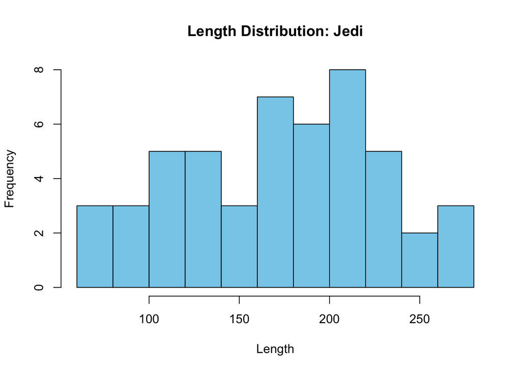

```r
# a
# Separate histograms by species (jedi or sith)
hist(magic_guys$length[magic_guys$species == "jedi"],
     main = "Length Distribution: Jedi",
     xlab = "Length",
     col = "skyblue",
     breaks = 10)
```

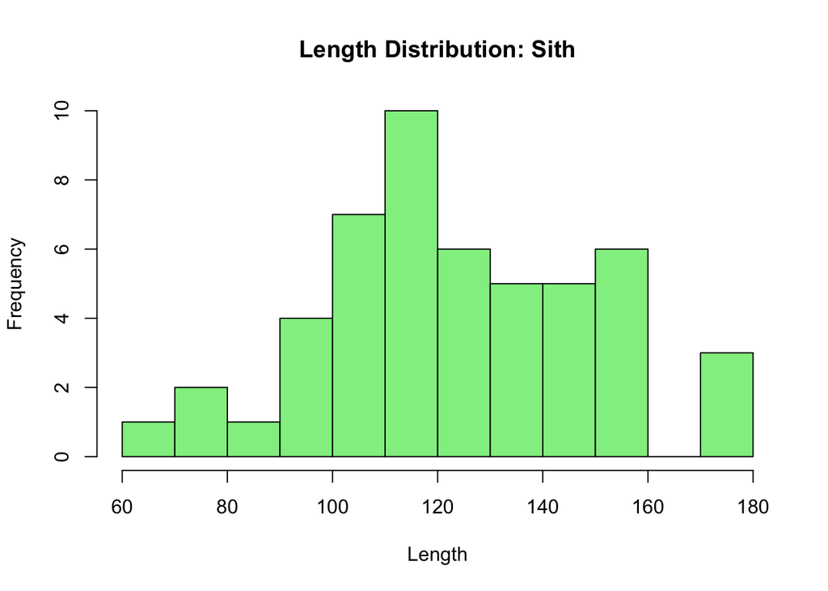

```r
hist(magic_guys$length[magic_guys$species == "sith"],
     main = "Length Distribution: Sith",
     xlab = "Length",
     col = "lightgreen",
     breaks = 10)
```

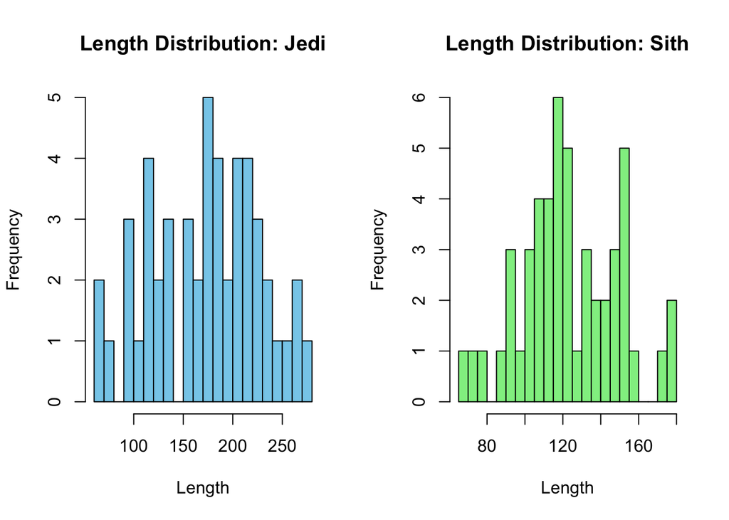

```r
# Side-by-side histograms for both Jedi and Sith
par(mfrow = c(1, 2))  # 1 row, 2 plots

hist(magic_guys$length[magic_guys$species == "jedi"],
     main = "Length Distribution: Jedi",
     xlab = "Length", col = "skyblue", breaks = 20)

hist(magic_guys$length[magic_guys$species == "sith"],
     main = "Length Distribution: Sith",
     xlab = "Length", col = "lightgreen", breaks = 20)
```

```r
par(mfrow = c(1, 1))  # reset layout
```

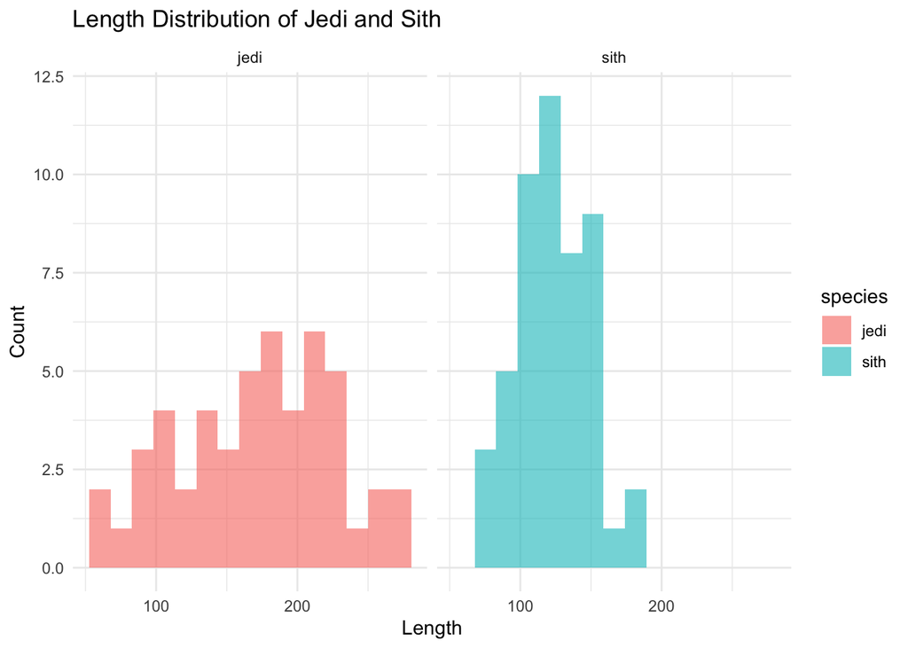

```r
# 1 ggplot

library(ggplot2)

ggplot(magic_guys, aes(x = length, fill = species)) +
  geom_histogram(alpha = 0.6, position = "identity", bins = 15) +
  facet_wrap(~species) +
  labs(title = "Length Distribution of Jedi and Sith",
       x = "Length", y = "Count") +
  theme_minimal()
```

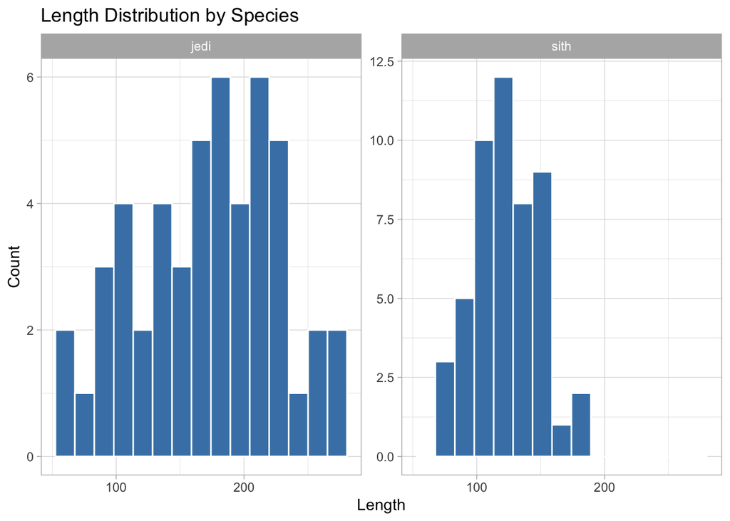

```r
# Faceted histograms: one panel per species
ggplot(magic_guys, aes(x = length, fill = species)) +
  geom_histogram(bins = 15, fill = "steelblue", color = "white") +
  facet_wrap(~species, scales = "free_y") +
  labs(title = "Length Distribution by Species",
       x = "Length", y = "Count") +
  theme_light()
```

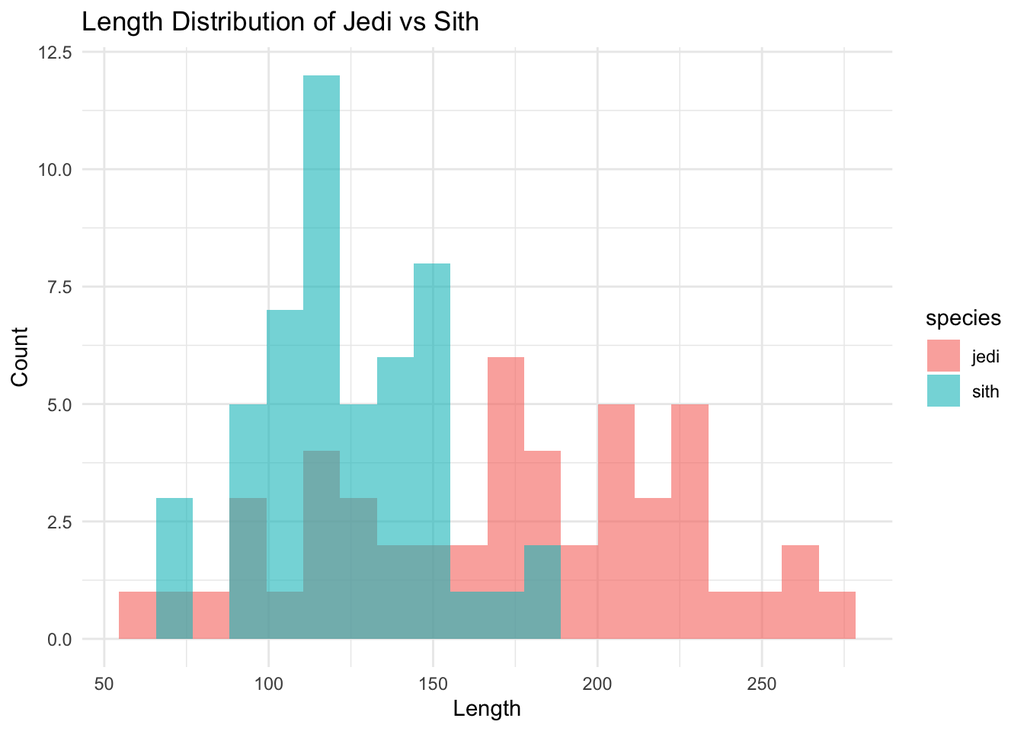

```r
# Overlay Jedi & Sith in one plot (with transparent fill)
ggplot(magic_guys, aes(x = length, fill = species)) +
  geom_histogram(alpha = 0.6, bins = 20, position = "identity") +
  labs(title = "Length Distribution of Jedi vs Sith",
       x = "Length", y = "Count") +
  theme_minimal()
```

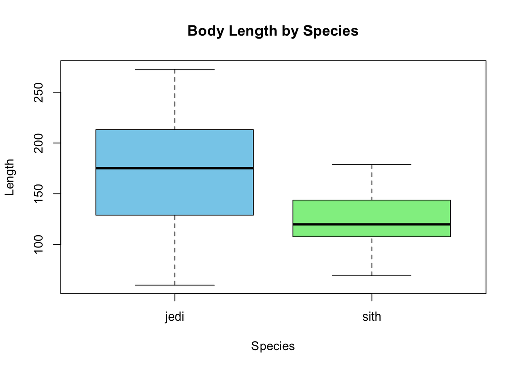

```r
# 1 b
boxplot(length ~ species, data = magic_guys,
        main = "Body Length by Species",
        xlab = "Species", ylab = "Length",
        col = c("skyblue", "lightgreen"))
```

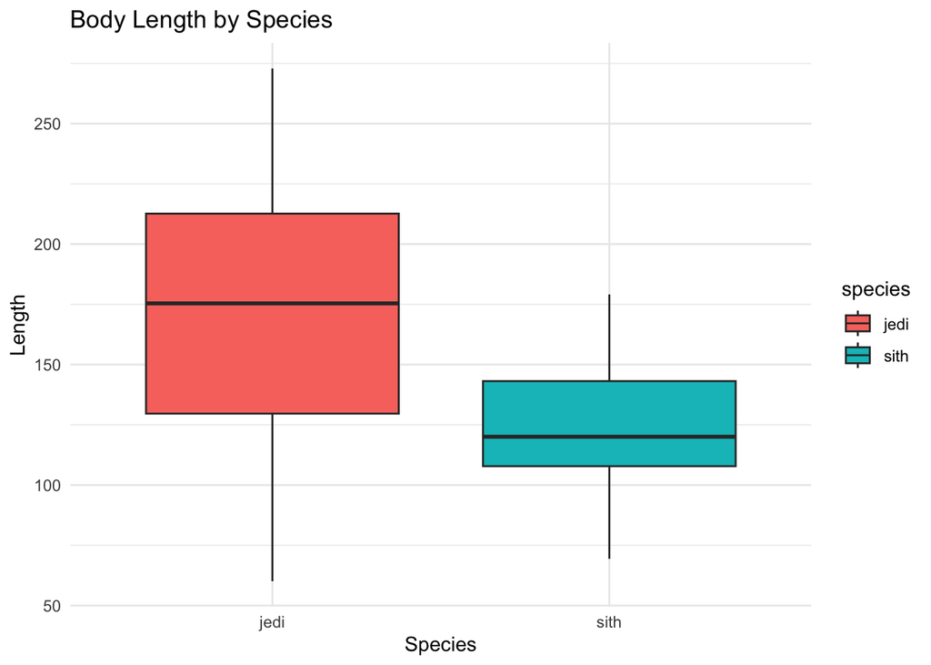

```r
ggplot(magic_guys, aes(x = species, y = length, fill = species)) +
  geom_boxplot() +
  labs(title = "Body Length by Species",
       x = "Species", y = "Length") +
  theme_minimal()
```

```r
# 1c

# PNG
png("boxplot_length.png", width = 800, height = 600)
ggplot(magic_guys, aes(x = species, y = length, fill = species)) +
  geom_boxplot() +
  labs(title = "Body Length by Species",
       x = "Species", y = "Length") +
  theme_minimal()
dev.off()
```

```r
# PDF
pdf("boxplot_length.pdf", width = 8, height = 6)
ggplot(magic_guys, aes(x = species, y = length, fill = species)) +
  geom_boxplot() +
  labs(title = "Body Length by Species",
       x = "Species", y = "Length") +
  theme_minimal()
dev.off()
```

```r
# SVG
svg("boxplot_length.svg", width = 8, height = 6)
ggplot(magic_guys, aes(x = species, y = length, fill = species)) +
  geom_boxplot() +
  labs(title = "Body Length by Species",
       x = "Species", y = "Length") +
  theme_minimal()
dev.off()
```

```r
# In which situation would you use which file format?
# PNG: Raster format: good for slides, web
# PDF: Vector format: good for printing and publication
# SVG: Vector format: good for editing in Illustrator
```

```r
# 2
microarray <- read.delim("Data/microarray_data.tab", header = TRUE, stringsAsFactors = FALSE)
head(microarray)
```

[output not shown]

[output cut: 622 more lines]

```r
dim(microarray)
```

```
## [1]  553 1000
```

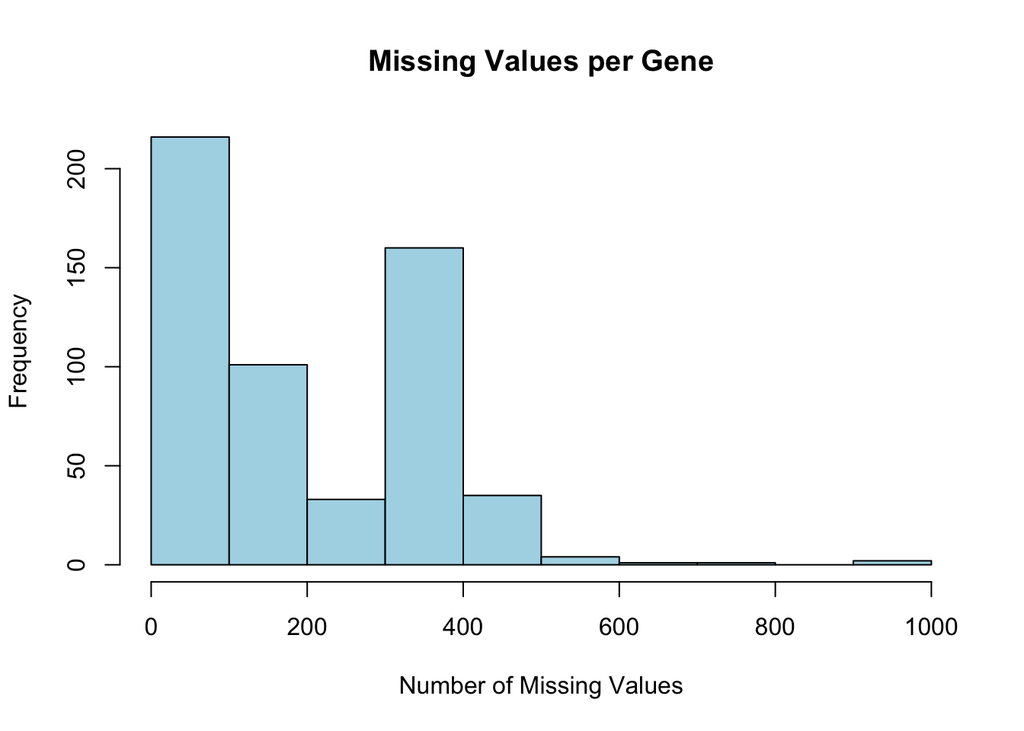

```r
# 2 b
missing_per_gene <- rowSums(is.na(microarray)) #count NAs per row

# Visualize first using histogram
hist(missing_per_gene,
     main = "Missing Values per Gene",
     xlab = "Number of Missing Values",
     col = "lightblue",
     breaks = 10)
```

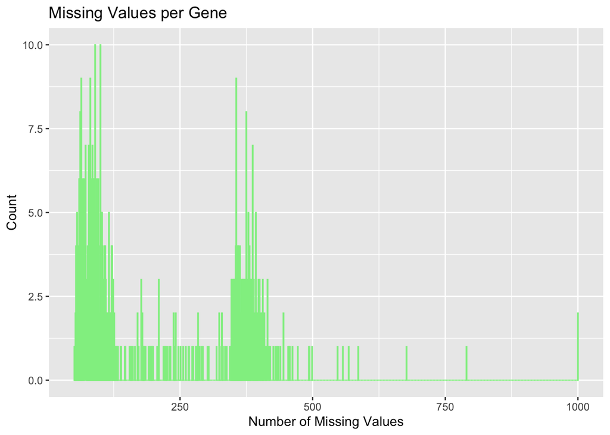

```r
# Visualize using ggplot
ggplot(data.frame(Missing = missing_per_gene), aes(x = Missing)) +
  geom_histogram(binwidth = 1, fill = "skyblue", color = "lightgreen") +
  labs(title = "Missing Values per Gene", x = "Number of Missing Values", y = "Count")
```

```r
# 2 c
missing_percent <- missing_per_gene / ncol(microarray) * 100 # Calculate percentage of missing values per gene

# Thresholds
genes_10 <- rownames(microarray)[missing_percent > 10]
genes_20 <- rownames(microarray)[missing_percent > 20]
genes_50 <- rownames(microarray)[missing_percent > 50]

length(genes_10)  # number of genes >10% missing
```

```
## [1] 337
```

```r
length(genes_20)
```

```
## [1] 236
```

```r
length(genes_50)
```

```
## [1] 8
```

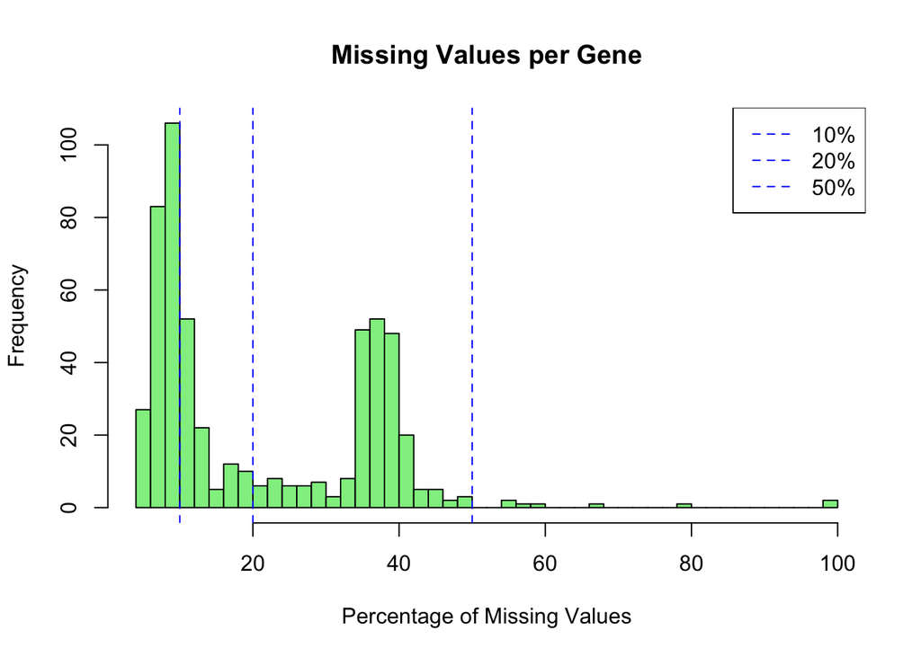

```r
# If I optionally wanted to visualize which genes exceed the threashold
missing_percent <- rowSums(is.na(microarray)) / ncol(microarray) * 100

hist(missing_percent,
     breaks = 40,
     col = "lightgreen",
     xlab = "Percentage of Missing Values",
     main = "Missing Values per Gene")
abline(v = c(10, 20, 50), col = "blue", lty = 2)  # thresholds
legend("topright", legend = c("10%", "20%", "50%"), col = "blue", lty = 2)
```

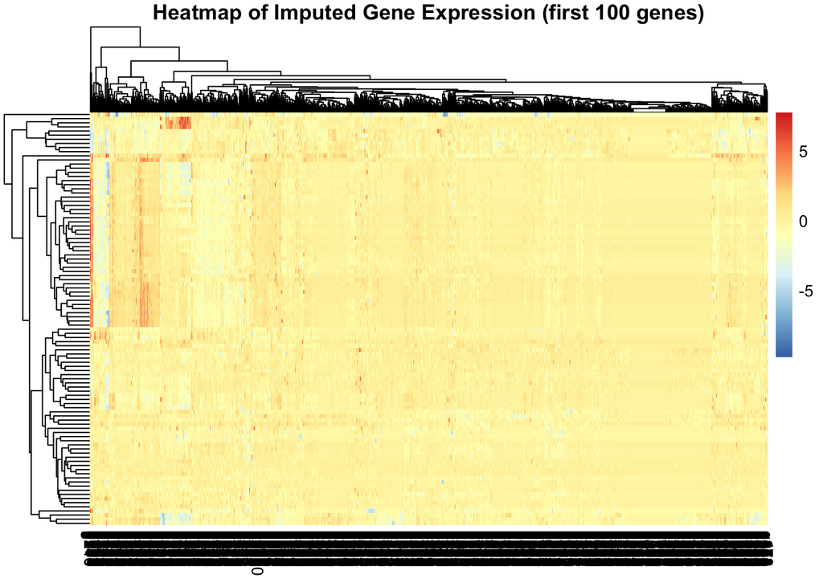

```r
# 2 d
# To replace NAs by row mean
impute_row_mean <- function(x) {
  ifelse(is.na(x), mean(x, na.rm = TRUE), x)
}

# Apply to each row
microarray_imputed <- t(apply(microarray, 1, impute_row_mean))

# Convert back to data.frame if needed
microarray_imputed <- as.data.frame(microarray_imputed)

library(pheatmap)
# Convert to numeric matrix
microarray_mat <- as.matrix(microarray_imputed)
# Heatmap of the first 100 genes for clarity
pheatmap(microarray_mat[1:100, ], cluster_rows = TRUE, cluster_cols = TRUE,
         main = "Heatmap of Imputed Gene Expression (first 100 genes)")
```

```r
# 3
data(CO2)
head(CO2)
```

```
##   Plant   Type  Treatment conc uptake
## 1   Qn1 Quebec nonchilled   95   16.0
## 2   Qn1 Quebec nonchilled  175   30.4
## 3   Qn1 Quebec nonchilled  250   34.8
## 4   Qn1 Quebec nonchilled  350   37.2
## 5   Qn1 Quebec nonchilled  500   35.3
## 6   Qn1 Quebec nonchilled  675   39.2
```

```r
str(CO2)
```

```
## Classes 'nfnGroupedData', 'nfGroupedData', 'groupedData' and 'data.frame':   84 obs. of  5 variables:
##  $ Plant    : Ord.factor w/ 12 levels "Qn1"<"Qn2"<"Qn3"<..: 1 1 1 1 1 1 1 2 2 2 ...
##  $ Type     : Factor w/ 2 levels "Quebec","Mississippi": 1 1 1 1 1 1 1 1 1 1 ...
##  $ Treatment: Factor w/ 2 levels "nonchilled","chilled": 1 1 1 1 1 1 1 1 1 1 ...
##  $ conc     : num  95 175 250 350 500 675 1000 95 175 250 ...
##  $ uptake   : num  16 30.4 34.8 37.2 35.3 39.2 39.7 13.6 27.3 37.1 ...
##  - attr(*, "formula")=Class 'formula'  language uptake ~ conc | Plant
##   .. ..- attr(*, ".Environment")=<environment: R_EmptyEnv>
##  - attr(*, "outer")=Class 'formula'  language ~Treatment * Type
##   .. ..- attr(*, ".Environment")=<environment: R_EmptyEnv>
##  - attr(*, "labels")=List of 2
##   ..$ x: chr "Ambient carbon dioxide concentration"
##   ..$ y: chr "CO2 uptake rate"
##  - attr(*, "units")=List of 2
##   ..$ x: chr "(uL/L)"
##   ..$ y: chr "(umol/m^2 s)"
```

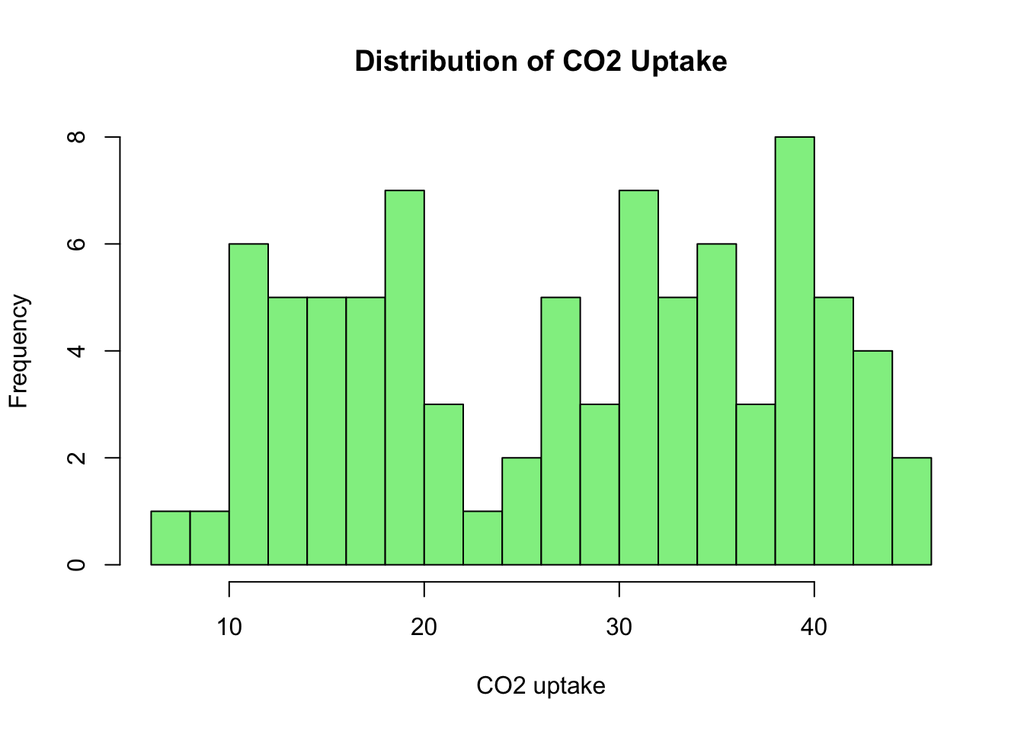

```r
hist(CO2$uptake,
     breaks = 20,
     col = "lightgreen",
     main = "Distribution of CO2 Uptake",
     xlab = "CO2 uptake")
```

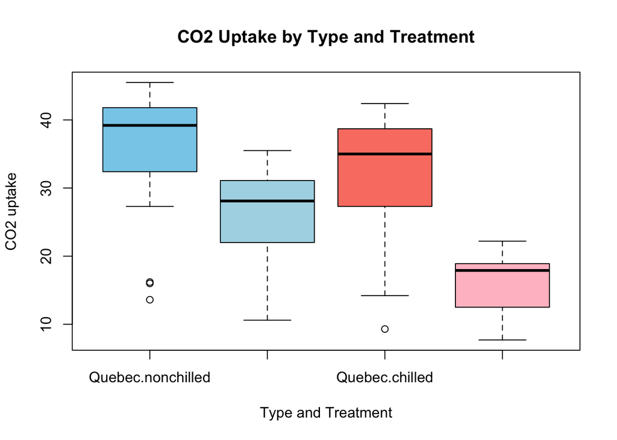

```r
# Boxplot by type and treatment to see differences between Quebec and Mississippi plants under different treatments.
boxplot(uptake ~ Type * Treatment, data = CO2,
        col = c("skyblue","lightblue","salmon","pink"),
        main = "CO2 Uptake by Type and Treatment",
        xlab = "Type and Treatment", ylab = "CO2 uptake")
```

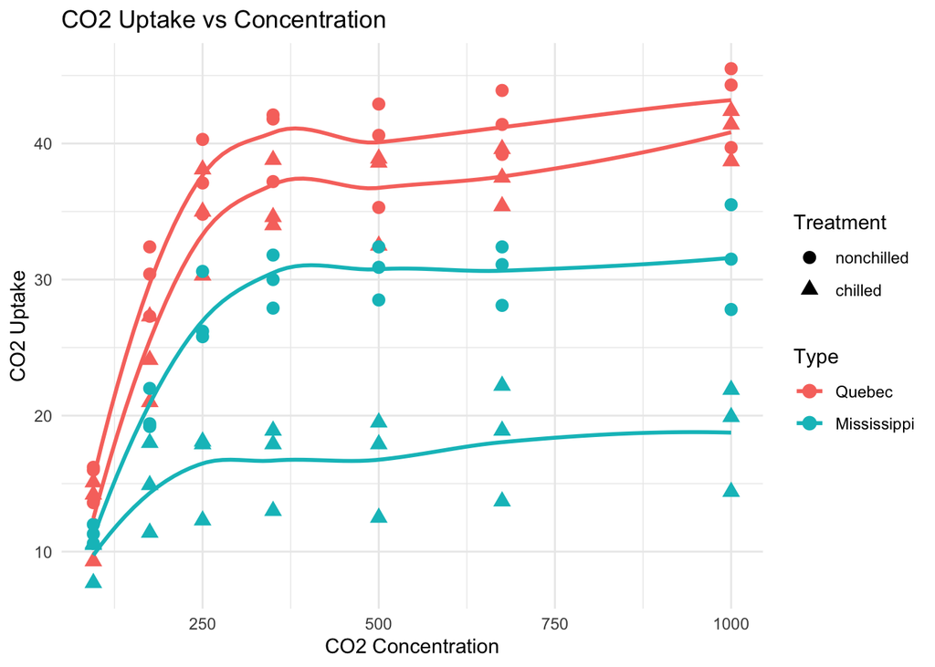

```r
# Scatter plot of uptake vs concentration to show the relationship between the two
ggplot(CO2, aes(x = conc, y = uptake, color = Type, shape = Treatment)) +
  geom_point(size = 3) +
  geom_smooth(method = "loess", se = FALSE) +
  labs(title = "CO2 Uptake vs Concentration",
       x = "CO2 Concentration", y = "CO2 Uptake") +
  theme_minimal()
```

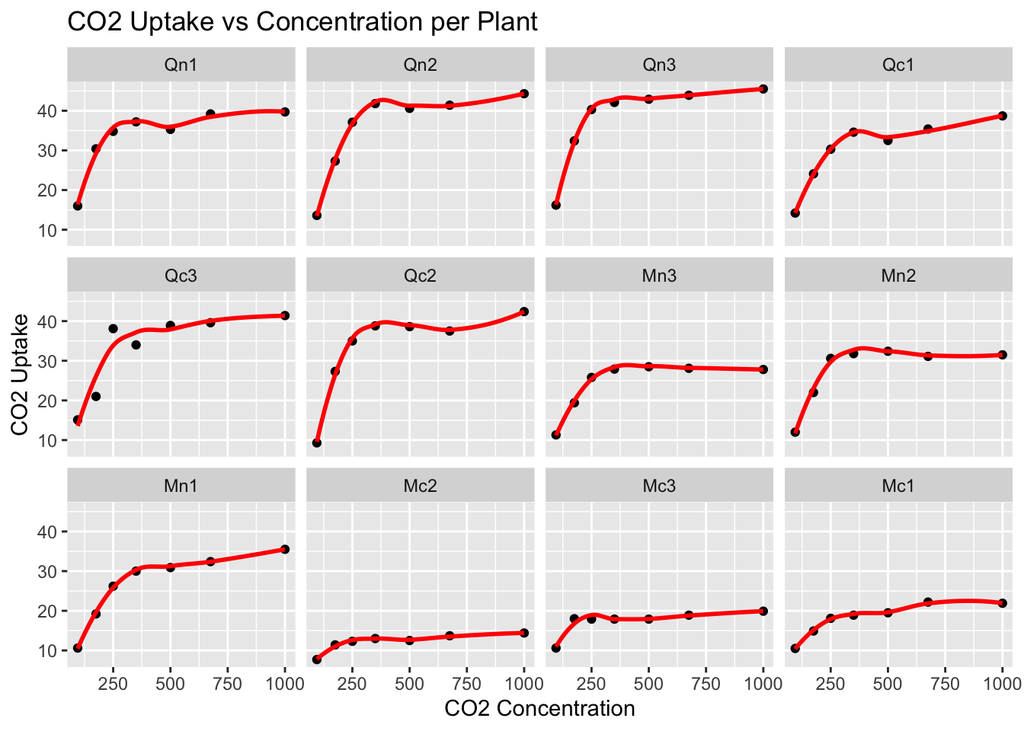

```r
# Faceted plot by plant to see variation between individual plants.
ggplot(CO2, aes(x = conc, y = uptake)) +
  geom_point(color = "black") +
  geom_smooth(method = "loess", se = FALSE, color = "red") +
  facet_wrap(~Plant) +
  labs(title = "CO2 Uptake vs Concentration per Plant",
       x = "CO2 Concentration", y = "CO2 Uptake")
```

```r
#non linear
fm1 <- nls(uptake ~ SSasymp(conc, Asym, lrc, c0), data = CO2, subset = Plant == "Qn1")
summary (fm1)
```

```
##
## Formula: uptake ~ SSasymp(conc, Asym, lrc, c0)
##
## Parameters:
##      Estimate Std. Error t value Pr(>|t|)
## Asym  38.1398     0.9164  41.620 1.99e-06 ***
## lrc  -34.2766    18.9661  -1.807    0.145
## c0    -4.3806     0.2042 -21.457 2.79e-05 ***
## ---
## Signif. codes:  0 '***' 0.001 '**' 0.01 '*' 0.05 '.' 0.1 ' ' 1
##
## Residual standard error: 1.663 on 4 degrees of freedom
##
## Number of iterations to convergence: 0
## Achieved convergence tolerance: 1.664e-06
```

```r
fmlist <- list()
for (pp in levels(CO2$Plant)){
  fmlist[[pp]] <- nls(uptake ~ SSasymp(conc, Asym, lrc, c0),
                      data = CO2, subset = Plant == pp)
}
print(sapply(fmlist, coef), digits =3)
```

```
##         Qn1    Qn2    Qn3   Qc1    Qc3    Qc2    Mn3    Mn2   Mn1   Mc2     Mc3
## Asym  38.14  42.87  44.23 36.43  40.68  39.82  28.48  32.13 34.08 13.56   18.54
## lrc  -34.28 -29.66 -37.63 -9.90 -11.54 -51.53 -17.37 -29.04 -8.81 -1.98 -136.11
## c0    -4.38  -4.67  -4.49 -4.86  -4.95  -4.46  -4.59  -4.47 -5.06 -4.56   -3.47
##        Mc1
## Asym 21.79
## lrc   2.45
## c0   -5.14
```

```r
## check correlations
# Correlation for Quebec Chilled
quebec_chilled_data <- subset(CO2, Type == "Quebec" & Treatment == "chilled")
correlation_quebec_chilled <- cor(quebec_chilled_data$uptake, quebec_chilled_data$conc)
print(correlation_quebec_chilled)
```

```
## [1] 0.7422454
```

```r
# Correlation for Quebec Nonchilled
quebec_nonchilled_data <- subset(CO2, Type == "Quebec" & Treatment == "nonchilled")
correlation_quebec_nonchilled <- cor(quebec_nonchilled_data$uptake, quebec_nonchilled_data$conc)
print(correlation_quebec_nonchilled)
```

```
## [1] 0.7038936
```

```r
# Correlation for Mississippi Chilled
mississippi_chilled_data <- subset(CO2, Type == "Mississippi" & Treatment == "chilled")
correlation_mississippi_chilled <- cor(mississippi_chilled_data$uptake, mississippi_chilled_data$conc)
print(correlation_mississippi_chilled)
```

```
## [1] 0.5586601
```

```r
# Correlation for Mississippi Nonchilled
mississippi_nonchilled_data <- subset(CO2, Type == "Mississippi" & Treatment == "nonchilled")
correlation_mississippi_nonchilled <- cor(mississippi_nonchilled_data$uptake, mississippi_nonchilled_data$conc)
print(correlation_mississippi_nonchilled)
```

```
## [1] 0.7019991
```

```r
# Dicussion
# The data showed clear plateau in CO2 uptake between 250-400 umol/mol, with strong correlation before that range.
```

## Task 8

```r
# Install devtools
#install.packages("devtools")
library(devtools)
# Install tidybiology from GitHub
#devtools::install_github("hirscheylab/tidybiology")
library(tidybiology)
```

```r
# 1a
# Load chromosome dataset
library(tidyverse)
data("chromosome")
colnames(chromosome)
```

```
##  [1] "id"                     "length_mm"              "basepairs"
##  [4] "variations"             "protein_codinggenes"    "pseudo_genes"
##  [7] "totallongnc_rna"        "totalsmallnc_rna"       "mi_rna"
## [10] "r_rna"                  "sn_rna"                 "sno_rna"
## [13] "miscnc_rna"             "centromereposition_mbp"
```

```r
chromosome_summary <- chromosome %>%
  summarise(
    mean_variations = mean(variations, na.rm = TRUE),
    median_variations = median(variations, na.rm = TRUE),
    max_variations = max(variations, na.rm = TRUE),

    mean_protein_coding_genes = mean(protein_codinggenes, na.rm = TRUE),
    median_protein_coding_genes = median(protein_codinggenes, na.rm = TRUE),
    max_protein_coding_genes = max(protein_codinggenes, na.rm = TRUE),

    mean_miRNAs = mean(mi_rna, na.rm = TRUE),
    median_miRNAs = median(mi_rna, na.rm = TRUE),
    max_miRNAs = max(mi_rna, na.rm = TRUE)
  )

chromosome_summary
```

```
## # A tibble: 1 × 9
##   mean_variations median_variations max_variations mean_protein_coding_genes
##             <dbl>             <dbl>          <dbl>                     <dbl>
## 1        6484572.           6172346       12945965                      850.
## # ℹ 5 more variables: median_protein_coding_genes <dbl>,
## #   max_protein_coding_genes <int>, mean_miRNAs <dbl>, median_miRNAs <dbl>,
## #   max_miRNAs <int>
```

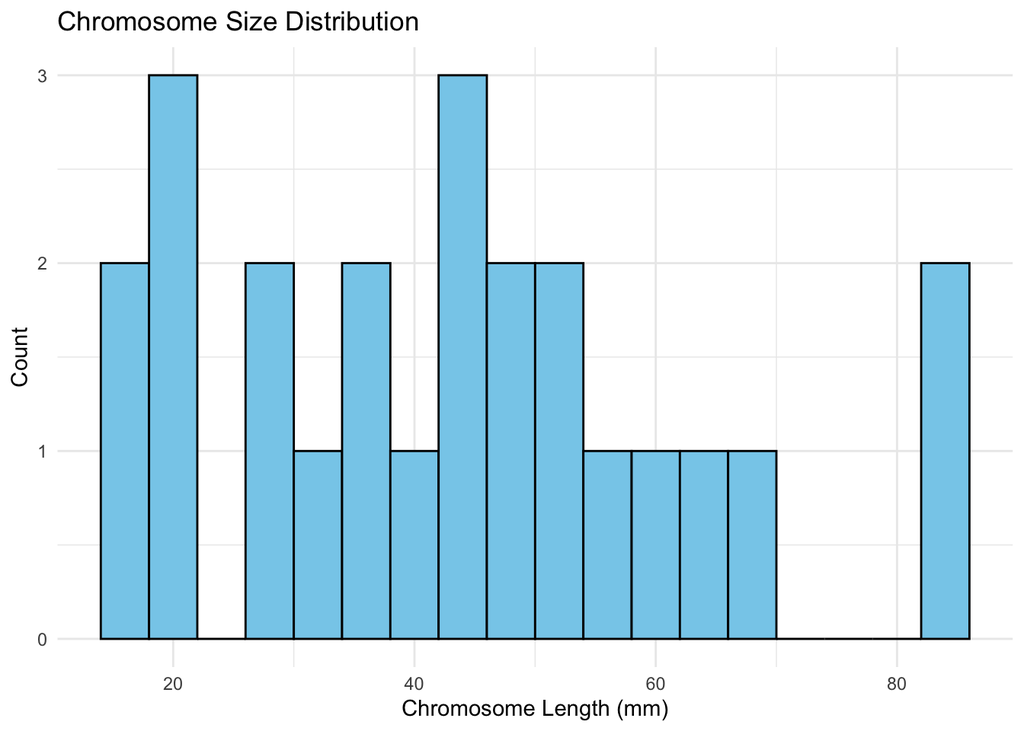

```r
# 1 b
ggplot(chromosome, aes(x = length_mm)) +
  geom_histogram(binwidth = 4, fill = "skyblue", color = "black") +
  labs(title = "Chromosome Size Distribution",
       x = "Chromosome Length (mm)", y = "Count") +
  theme_minimal()
```

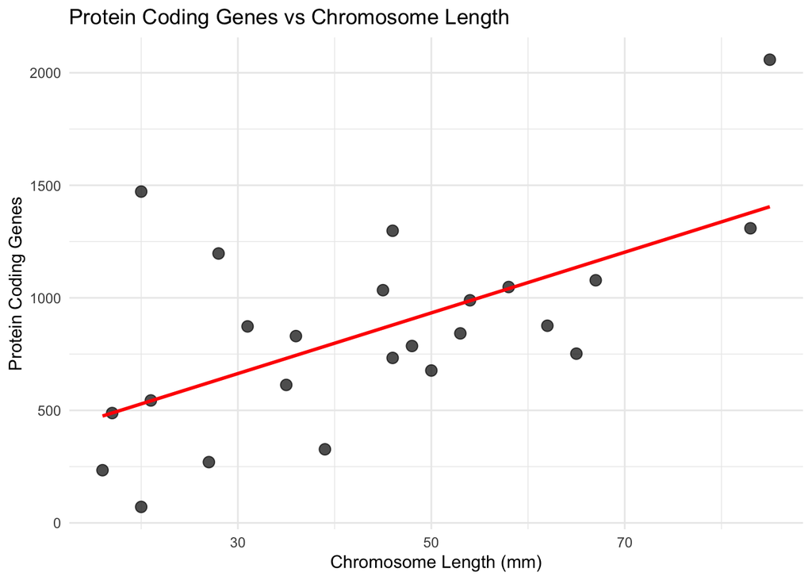

```r
# 1 C

# chromosome length vs protein coding genes
ggplot(chromosome, aes(x = length_mm, y = protein_codinggenes)) +
  geom_point(color = "black", size = 3, alpha = 0.7) +
  geom_smooth(method = "lm", se = FALSE, color = "red") +
  labs(title = "Protein Coding Genes vs Chromosome Length",
       x = "Chromosome Length (mm)", y = "Protein Coding Genes") +
  theme_minimal()
```

```r
# Fit linear model
lm_protein <- lm(protein_codinggenes ~ length_mm, data = chromosome)
# Get R²
summary(lm_protein)$r.squared
```

```
## [1] 0.3672585
```

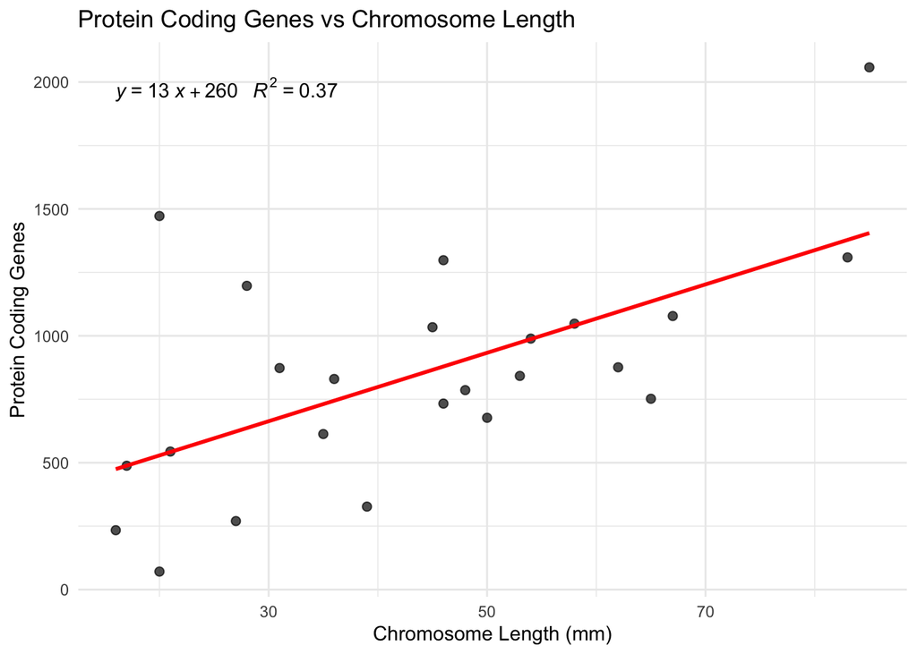

```r
library(ggpubr)

ggplot(chromosome, aes(x = length_mm, y = protein_codinggenes)) +
  geom_point(color = "black", size = 2, alpha = 0.7) +
  geom_smooth(method = "lm", se = FALSE, color = "red") +
  stat_regline_equation(aes(label = paste(..eq.label.., ..rr.label.., sep = "~~~"))) +
  labs(title = "Protein Coding Genes vs Chromosome Length",
       x = "Chromosome Length (mm)", y = "Protein Coding Genes") +
  theme_minimal()
```

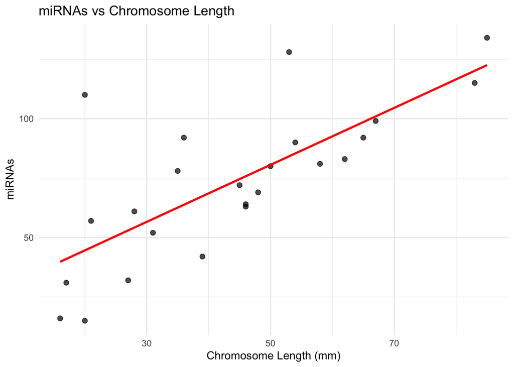

```r
# chromosome length vs miRNAs
ggplot(chromosome, aes(x = length_mm, y = mi_rna)) +
  geom_point(color = "black", size = 2, alpha = 0.7) +
  geom_smooth(method = "lm", se = FALSE, color = "red") +
  labs(title = "miRNAs vs Chromosome Length",
       x = "Chromosome Length (mm)", y = "miRNAs") +
  theme_minimal()
```

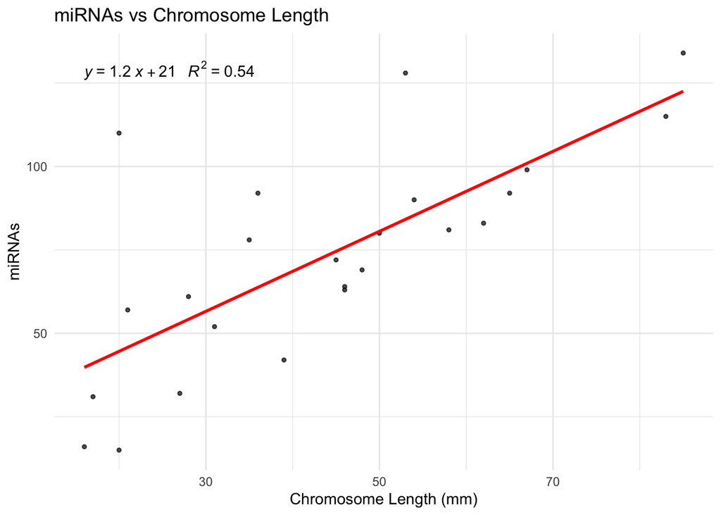

```r
# To find R2 and add it to the correlation plot
ggplot(chromosome, aes(x = length_mm, y = mi_rna)) +
  geom_point(color = "black", size = 1, alpha = 0.7) +
  geom_smooth(method = "lm", se = FALSE, color = "red") +
  stat_regline_equation(aes(label = paste(..eq.label.., ..rr.label.., sep = "~~~"))) +
  labs(title = "miRNAs vs Chromosome Length",
       x = "Chromosome Length (mm)", y = "miRNAs") +
  theme_minimal()
```

```r
# 1 d
# Load data
data("proteins")
head(proteins)
```

```
## # A tibble: 6 × 8
##   uniprot_id gene_name gene_name_alt   protein_name    protein_name_alt sequence
##   <chr>      <chr>     <chr>           <chr>           <chr>            <chr>
## 1 P04217     A1BG      <NA>            "Alpha-1B-glyc… Alpha-1-B glyco… MSMLVVF…
## 2 Q9NQ94     A1CF      ACF ASP         "APOBEC1 compl… APOBEC1-stimula… MESNHKS…
## 3 P01023     A2M       CPAMD5 FWP007   "Alpha-2-macro… Alpha-2-M) (C3 … MGKNKLL…
## 4 A8K2U0     A2ML1     CPAMD9          "Alpha-2-macro… C3 and PZP-like… MWAQLLL…
## 5 U3KPV4     A3GALT2   A3GALT2P IGBS3S "Alpha-1,3-gal… EC 2.4.1.87) (I… MALKEGL…
## 6 Q9NPC4     A4GALT    A14GALT A4GALT1 "Lactosylceram… EC 2.4.1.228) (… MSKPPDL…
## # ℹ 2 more variables: length <dbl>, mass <dbl>
```

```r
str(proteins)
```

```
## tibble [20,430 × 8] (S3: tbl_df/tbl/data.frame)
##  $ uniprot_id      : chr [1:20430] "P04217" "Q9NQ94" "P01023" "A8K2U0" ...
##  $ gene_name       : chr [1:20430] "A1BG" "A1CF" "A2M" "A2ML1" ...
##  $ gene_name_alt   : chr [1:20430] NA "ACF ASP" "CPAMD5 FWP007" "CPAMD9" ...
##  $ protein_name    : chr [1:20430] "Alpha-1B-glycoprotein " "APOBEC1 complementation factor " "Alpha-2-macroglobulin " "Alpha-2-macroglobulin-like protein 1 " ...
##  $ protein_name_alt: chr [1:20430] "Alpha-1-B glycoprotein)" "APOBEC1-stimulating protein)" "Alpha-2-M) (C3 and PZP-like alpha-2-macroglobulin domain-containing protein 5)" "C3 and PZP-like alpha-2-macroglobulin domain-containing protein 9)" ...
##  $ sequence        : chr [1:20430] "MSMLVVFLLLWGVTWGPVTEAAIFYETQPSLWAESESLLKPLANVTLTCQAHLETPDFQLFKNGVAQEPVHLDSPAIKHQFLLTGDTQGRYRCRSGLSTGWTQLSKLLELT"| __truncated__ "MESNHKSGDGLSGTQKEAALRALVQRTGYSLVQENGQRKYGGPPPGWDAAPPERGCEIFIGKLPRDLFEDELIPLCEKIGKIYEMRMMMDFNGNNRGYAFVTFSNKVEAKN"| __truncated__ "MGK…
##  $ length          : num [1:20430] 495 594 1474 1454 340 ...
##  $ mass            : num [1:20430] 54254 65202 163291 161107 38754 ...
```

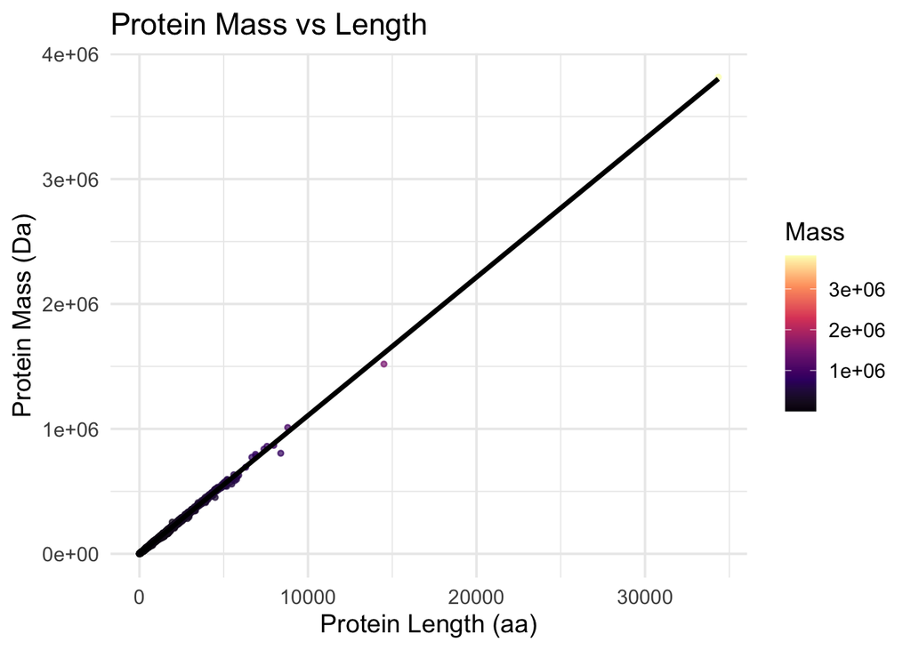

```r
# Get the summary stats
library(dplyr)

proteins_summary <- proteins %>%
  summarise(
    mean_length = mean(length, na.rm = TRUE),
    median_length = median(length, na.rm = TRUE),
    max_length = max(length, na.rm = TRUE),

    mean_mass = mean(mass, na.rm = TRUE),
    median_mass = median(mass, na.rm = TRUE),
    max_mass = max(mass, na.rm = TRUE)
  )

# To plot in a scatter plot the length vs mass
library(viridis)  # for nice color palette
ggplot(proteins, aes(x = length, y = mass)) +
  geom_point(aes(color = mass), alpha = 0.7, size = 1) +
  geom_smooth(method = "lm", se = FALSE, color = "black") +
  scale_color_viridis_c(option = "A") +
  labs(title = "Protein Mass vs Length",
       x = "Protein Length (aa)",
       y = "Protein Mass (Da)",
       color = "Mass") +
  theme_minimal(base_size = 14) +
  theme(legend.position = "right")
```

```r
proteins_summary
```

```
## # A tibble: 1 × 6
##   mean_length median_length max_length mean_mass median_mass max_mass
##         <dbl>         <dbl>      <dbl>     <dbl>       <dbl>    <dbl>
## 1        557.           414      34350    62061.      46140.  3816030
```